# Problem Set #3 — Computing the Aiyagari Economy

#### Q3(a)(iii)

Given the policy function $g$, characterize the invariant distribution of wealth $a \in \mathcal{A}$. Compute the level of aggregate wealth, denoted $E_a(q)$ associate to each $q$. Produce the graph with $K(q)$ and $E_a(q)$ for all the $q$ in the grid. Indicate which one(s) correspond to the (approximate) stationary equilibrium if any. If none, discuss how you amended your code to sort it out (e.g. finer grids, an alternative iterative algorithm, etc. Yes, that is the right attitude!!)

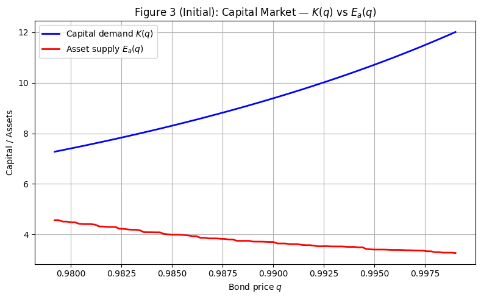

```
K(q) range: [7.27, 12.01]
Ea(q) range: [3.27, 4.57]
K(q) - Ea(q) is always positive: True
Smallest gap = 2.7077 at q = 0.9792

=> The curves do NOT cross on this grid. No equilibrium found!
```

```python
# Q3(a)(iii): Initial attempt — Graph K(q) vs E_a(q)
fig, ax = plt.subplots(figsize=(8, 5))
ax.plot(q_grid, K_demand, 'b-', linewidth=2, label=r'Capital demand $K(q)$')
ax.plot(q_grid, Ea_all, 'r-', linewidth=2, label=r'Asset supply $E_a(q)$')
ax.set_xlabel('Bond price $q$')
ax.set_ylabel('Capital / Assets')
ax.set_title('Figure 3 (Initial): Capital Market — $K(q)$ vs $E_a(q)$')
ax.legend()
ax.grid(True)
plt.tight_layout()
plt.show()

# Check: do the curves cross?
print(f"K(q) range: [{K_demand.min():.2f}, {K_demand.max():.2f}]")
print(f"Ea(q) range: [{Ea_all.min():.2f}, {Ea_all.max():.2f}]")
gap = K_demand - Ea_all
print(f"K(q) - Ea(q) is always positive: {np.all(gap > 0)}")
print(f"Smallest gap = {gap.min():.4f} at q = {q_grid[np.argmin(gap)]:.4f}")
print("\n=> The curves do NOT cross on this grid. No equilibrium found!")
```

**Diagnosing the problem:** With the prescribed grid $q \in [1.02\beta,\; 0.999]$, the capital demand curve $K(q)$ lies strictly above the asset supply curve $E_a(q)$ for all grid points — the curves never cross, so no equilibrium is found.

The issue is that the lower bound $1.02\beta \approx 0.9792$ is too far from $\beta$. As $q \to \beta^+$, the interest rate approaches $1/\beta - 1$, which makes precautionary savings very large ($E_a(q) \to \infty$). Meanwhile, $K(q)$ remains finite. The crossing must therefore occur at some $q$ between $\beta$ and $1.02\beta$, which our grid misses entirely.

**Fix:** We bring the lower bound closer to $\beta$ (using $1.002\beta$ instead of $1.02\beta$) and increase the asset grid upper bound to $a_{\max} = 200$ to accommodate the larger wealth accumulation near $\beta$. We also increase the asset grid to $N_a = 500$ for accuracy.

```python
# Q3(a)(iii) — Corrected computation with finer grid near beta
N_a = 500
a_max = 200.0
a_grid = np.linspace(0, a_max, N_a)

N_q = 100
q_grid = np.linspace(1.002 * beta, 0.999, N_q)

print("Re-solving with corrected grid...")
print(f"  q range: [{q_grid[0]:.6f}, {q_grid[-1]:.6f}]  (beta = {beta})")
print(f"  a_max = {a_max}, N_a = {N_a}")

V_all = []
g_all = []
g_idx_all = []
dist_all = []
Ea_all = np.zeros(N_q)
K_demand = np.zeros(N_q)

for iq, q_val in enumerate(q_grid):
    V, g, g_idx = solve_vfi(q_val)
    V_all.append(V)
    g_all.append(g)
    g_idx_all.append(g_idx)

    dist = compute_stationary_dist(g_idx)
    dist_all.append(dist)
    Ea_all[iq] = np.sum(a_grid[:, None] * dist)
    K_demand[iq] = K_from_q(q_val)

    if (iq + 1) % 20 == 0:
        print(f"  [{iq+1:3d}/{N_q}] q={q_val:.4f}  K(q)={K_demand[iq]:7.2f}  Ea(q)={Ea_all[iq]:7.2f}")

# Find equilibrium
eq_idx = np.argmin(np.abs(K_demand - Ea_all))
q_star = q_grid[eq_idx]

print(f"\nEquilibrium found: q* ≈ {q_star:.4f}")
print(f"  K(q*)  = {K_demand[eq_idx]:.4f}")
print(f"  Ea(q*) = {Ea_all[eq_idx]:.4f}")
print(f"  |K - Ea| = {abs(K_demand[eq_idx] - Ea_all[eq_idx]):.4f}")
print(f"  r* = {r_from_q(q_star):.4f},  w* = {w_from_q(q_star):.4f}")

frac_at_top = np.sum(dist_all[eq_idx][-1, :])
print(f"  Fraction at a_max = {frac_at_top:.6f} (should be ≈ 0)")
```

```
Re-solving with corrected grid...
  q range: [0.961920, 0.999000]  (beta = 0.96)
  a_max = 200.0, N_a = 500
  [ 20/100] q=0.9690  K(q)=   5.90  Ea(q)=   9.32
  [ 40/100] q=0.9765  K(q)=   6.87  Ea(q)=   5.59
  [ 60/100] q=0.9840  K(q)=   8.11  Ea(q)=   4.49
  [ 80/100] q=0.9915  K(q)=   9.76  Ea(q)=   3.79
  [100/100] q=0.9990  K(q)=  12.01  Ea(q)=   3.33

Equilibrium found: q* ≈ 0.9735
  K(q*)  = 6.4501
  Ea(q*) = 6.5063
  |K - Ea| = 0.0562
  r* = 0.0772,  w* = 1.3854
  Fraction at a_max = 0.000000 (should be ≈ 0)
```

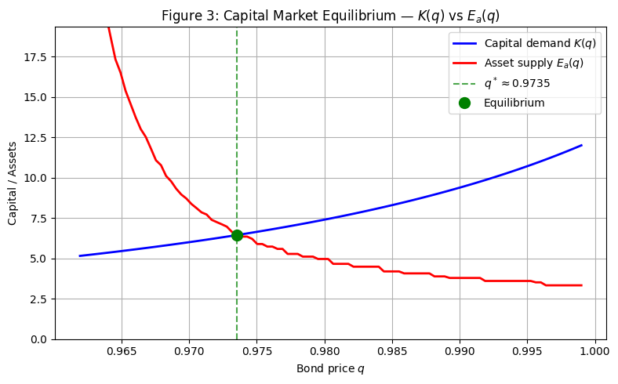

```
Equilibrium: q* ≈ 0.9735, K(q*) = 6.4501, Ea(q*) = 6.5063
```

```python
# Figure 3 (Corrected): K(q) vs E_a(q)
fig, ax = plt.subplots(figsize=(8, 5))
ax.plot(q_grid, K_demand, 'b-', linewidth=2, label=r'Capital demand $K(q)$')
ax.plot(q_grid, Ea_all, 'r-', linewidth=2, label=r'Asset supply $E_a(q)$')
ax.axvline(q_star, color='green', linestyle='--', alpha=0.7, label=f'$q^* \\approx {q_star:.4f}$')
ax.plot(q_star, K_demand[eq_idx], 'go', markersize=10, zorder=5, label='Equilibrium')

# Zoom to reasonable range so the crossing is visible
y_upper = min(max(K_demand.max(), Ea_all.max()), 3 * K_demand[eq_idx])
ax.set_ylim(0, y_upper)
ax.set_xlabel('Bond price $q$')
ax.set_ylabel('Capital / Assets')
ax.set_title('Figure 3: Capital Market Equilibrium — $K(q)$ vs $E_a(q)$')
ax.legend()
ax.grid(True)
plt.tight_layout()
plt.savefig('fig3_equilibrium.png', dpi=150)
plt.show()

print(f"Equilibrium: q* ≈ {q_star:.4f}, K(q*) = {K_demand[eq_idx]:.4f}, Ea(q*) = {Ea_all[eq_idx]:.4f}")
```

```python
# Figure 1: Value functions at corrected equilibrium q*
V_eq = V_all[eq_idx]

fig, ax = plt.subplots(figsize=(8, 5))
ax.plot(a_grid, V_eq[:, 0], label=f'$s_L = {s_L}$')
ax.plot(a_grid, V_eq[:, 1], label=f'$s_H = {s_H}$')
ax.set_xlabel('Assets $a$')
ax.set_ylabel('$V(a, s)$')
ax.set_title(f'Figure 1: Value Functions at $q^* = {q_star:.4f}$')
ax.legend()
ax.grid(True)
plt.tight_layout()
plt.savefig('fig1_value_functions.png', dpi=150)
plt.show()
```

[output not shown]

```python
# Figure 2: Policy functions at corrected equilibrium q*
g_eq = g_all[eq_idx]

fig, ax = plt.subplots(figsize=(8, 5))
ax.plot(a_grid, g_eq[:, 0], label=f'$s_L = {s_L}$')
ax.plot(a_grid, g_eq[:, 1], label=f'$s_H = {s_H}$')
ax.plot(a_grid, a_grid, 'k--', alpha=0.3, label='45° line')
ax.set_xlabel('Current Assets $a$')
ax.set_ylabel("Next Period Assets $a' = g(a, s)$")
ax.set_title(f'Figure 2: Policy Functions at $q^* = {q_star:.4f}$')
ax.legend()
ax.grid(True)
plt.tight_layout()
plt.savefig('fig2_policy_functions.png', dpi=150)
plt.show()
```

[output not shown]

### Question 4

Once you have sorted out the equilibrium $q$:

#### Q4(a)

Provide a graph of the distribution with the level of wealth in the horizontal axis and the fraction of households in the vertical axis. Provide similar graphs for the distribution of wealth conditional on the skill levels $s \in \{s_L, s_H\}$. Likewise, produce graphs of the consumption distributions.

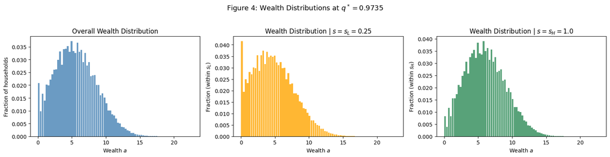

```
Fraction at a_max = 0.000000 (should be ≈ 0)
```

```python
# Q4(a): Wealth distribution (overall and conditional on s)
# Re-solve at equilibrium q* with a finer grid focused on the relevant wealth range
N_a_fine = 1000
a_max_fine = 30.0
a_grid_fine = np.linspace(0, a_max_fine, N_a_fine)

# Temporarily swap grids
a_grid_old, N_a_old = a_grid, N_a
a_grid, N_a = a_grid_fine, N_a_fine

V_eq_fine, g_eq_fine, g_idx_eq_fine = solve_vfi(q_star)
dist_eq_fine = compute_stationary_dist(g_idx_eq_fine)

# Restore original grid
a_grid, N_a = a_grid_old, N_a_old

# Marginal wealth distributions
dist_total = dist_eq_fine[:, 0] + dist_eq_fine[:, 1]
dist_sL = dist_eq_fine[:, 0]
dist_sH = dist_eq_fine[:, 1]

# Bin into wider buckets for smooth display
N_w_bins = 80
a_upper = a_grid_fine[np.max(np.where(dist_total > 1e-8))] * 1.1
w_bins = np.linspace(0, a_upper, N_w_bins + 1)
w_centers = 0.5 * (w_bins[:-1] + w_bins[1:])
bin_width = w_bins[1] - w_bins[0]

def bin_distribution(dist_vec, grid, bins):
    binned = np.zeros(len(bins) - 1)
    idx = np.digitize(grid, bins) - 1
    idx = np.clip(idx, 0, len(bins) - 2)
    for i in range(len(grid)):
        binned[idx[i]] += dist_vec[i]
    return binned

dist_total_binned = bin_distribution(dist_total, a_grid_fine, w_bins)
dist_sL_binned = bin_distribution(dist_sL, a_grid_fine, w_bins)
dist_sH_binned = bin_distribution(dist_sH, a_grid_fine, w_bins)

fig, axes = plt.subplots(1, 3, figsize=(16, 4))

axes[0].bar(w_centers, dist_total_binned, width=bin_width*0.9, color='steelblue', alpha=0.8)
axes[0].set_xlabel('Wealth $a$')
axes[0].set_ylabel('Fraction of households')
axes[0].set_title('Overall Wealth Distribution')

axes[1].bar(w_centers, dist_sL_binned / dist_sL_binned.sum(), width=bin_width*0.9, color='orange', alpha=0.8)
axes[1].set_xlabel('Wealth $a$')
axes[1].set_ylabel('Fraction (within $s_L$)')
axes[1].set_title(f'Wealth Distribution | $s = s_L = {s_L}$')

axes[2].bar(w_centers, dist_sH_binned / dist_sH_binned.sum(), width=bin_width*0.9, color='seagreen', alpha=0.8)
axes[2].set_xlabel('Wealth $a$')
axes[2].set_ylabel('Fraction (within $s_H$)')
axes[2].set_title(f'Wealth Distribution | $s = s_H = {s_H}$')

plt.suptitle(f'Figure 4: Wealth Distributions at $q^* = {q_star:.4f}$', y=1.02, fontsize=13)
plt.tight_layout()
plt.savefig('fig4_wealth_distributions.png', dpi=150, bbox_inches='tight')
plt.show()

frac_at_top_fine = np.sum(dist_eq_fine[-1, :])
print(f"Fraction at a_max = {frac_at_top_fine:.6f} (should be ≈ 0)")
```

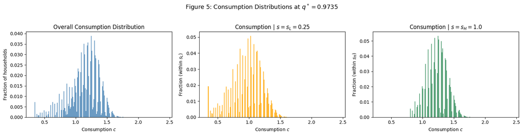

```python
# Q4(a): Consumption distributions (overall and conditional on s)
# Consumption: c(a, s) = w*s + a - q*g(a, s)
w_star = w_from_q(q_star)

# Consumption at each (a, s) pair on the fine grid
c_vals = np.zeros((N_a_fine, 2))
for j in range(2):
    c_vals[:, j] = w_star * s_vals[j] + a_grid_fine - q_star * g_eq_fine[:, j]

# Build consumption distribution by binning
N_c_bins = 200
c_min = c_vals[c_vals > 0].min() * 0.9
c_max = c_vals.max() * 1.1
c_bins = np.linspace(c_min, c_max, N_c_bins + 1)
c_centers = 0.5 * (c_bins[:-1] + c_bins[1:])

dist_c_total = np.zeros(N_c_bins)
dist_c_sL = np.zeros(N_c_bins)
dist_c_sH = np.zeros(N_c_bins)

for j in range(2):
    bin_idx = np.digitize(c_vals[:, j], c_bins) - 1
    bin_idx = np.clip(bin_idx, 0, N_c_bins - 1)
    for i in range(N_a_fine):
        dist_c_total[bin_idx[i]] += dist_eq_fine[i, j]
        if j == 0:
            dist_c_sL[bin_idx[i]] += dist_eq_fine[i, j]
        else:
            dist_c_sH[bin_idx[i]] += dist_eq_fine[i, j]

fig, axes = plt.subplots(1, 3, figsize=(16, 4))

axes[0].bar(c_centers, dist_c_total, width=c_bins[1]-c_bins[0], color='steelblue', alpha=0.8)
axes[0].set_xlabel('Consumption $c$')
axes[0].set_ylabel('Fraction of households')
axes[0].set_title('Overall Consumption Distribution')

axes[1].bar(c_centers, dist_c_sL / dist_c_sL.sum(), width=c_bins[1]-c_bins[0], color='orange', alpha=0.8)
axes[1].set_xlabel('Consumption $c$')
axes[1].set_ylabel('Fraction (within $s_L$)')
axes[1].set_title(f'Consumption | $s = s_L = {s_L}$')

axes[2].bar(c_centers, dist_c_sH / dist_c_sH.sum(), width=c_bins[1]-c_bins[0], color='seagreen', alpha=0.8)
axes[2].set_xlabel('Consumption $c$')
axes[2].set_ylabel('Fraction (within $s_H$)')
axes[2].set_title(f'Consumption | $s = s_H = {s_H}$')

plt.suptitle(f'Figure 5: Consumption Distributions at $q^* = {q_star:.4f}$', y=1.02, fontsize=13)
plt.tight_layout()
plt.savefig('fig5_consumption_distributions.png', dpi=150, bbox_inches='tight')
plt.show()
```

#### Q4(b)

Compute the basic statistics for the income and wealth distribution of your model, in particular, mean, std., skewness of wealth.

```python
# Q4(b): Mean, std, skewness of income and wealth (using fine grid)

# --- Wealth statistics ---
Ea = np.sum(a_grid_fine[:, None] * dist_eq_fine)
Ea2 = np.sum(a_grid_fine[:, None]**2 * dist_eq_fine)
Ea3 = np.sum(a_grid_fine[:, None]**3 * dist_eq_fine)

mean_wealth = Ea
var_wealth = Ea2 - Ea**2
std_wealth = np.sqrt(var_wealth)
skew_wealth = (Ea3 - 3*Ea*var_wealth - Ea**3) / (std_wealth**3)

print("=== Wealth Distribution Statistics ===")
print(f"Mean     = {mean_wealth:.4f}")
print(f"Std      = {std_wealth:.4f}")
print(f"Skewness = {skew_wealth:.4f}")

# --- Income statistics ---
r_star = r_from_q(q_star)
income = np.zeros((N_a_fine, 2))
for j in range(2):
    income[:, j] = w_star * s_vals[j] + (r_star - delta) * a_grid_fine

Ey = np.sum(income * dist_eq_fine)
Ey2 = np.sum(income**2 * dist_eq_fine)
Ey3 = np.sum(income**3 * dist_eq_fine)

mean_income = Ey
var_income = Ey2 - Ey**2
std_income = np.sqrt(var_income)
skew_income = (Ey3 - 3*Ey*var_income - Ey**3) / (std_income**3)

print("\n=== Income Distribution Statistics ===")
print(f"Mean     = {mean_income:.4f}")
print(f"Std      = {std_income:.4f}")
print(f"Skewness = {skew_income:.4f}")

# --- Consumption statistics ---
Ec = np.sum(c_vals * dist_eq_fine)
Ec2 = np.sum(c_vals**2 * dist_eq_fine)
Ec3 = np.sum(c_vals**3 * dist_eq_fine)

mean_cons = Ec
var_cons = Ec2 - Ec**2
std_cons = np.sqrt(var_cons)
skew_cons = (Ec3 - 3*Ec*var_cons - Ec**3) / (std_cons**3)

print("\n=== Consumption Distribution Statistics ===")
print(f"Mean     = {mean_cons:.4f}")
print(f"Std      = {std_cons:.4f}")
print(f"Skewness = {skew_cons:.4f}")

# Summary table
print("\n=== Summary Table ===")
print(f"{'':15s} {'Mean':>10s} {'Std':>10s} {'Skewness':>10s}")
print("-" * 47)
print(f"{'Wealth':15s} {mean_wealth:10.4f} {std_wealth:10.4f} {skew_wealth:10.4f}")
print(f"{'Income':15s} {mean_income:10.4f} {std_income:10.4f} {skew_income:10.4f}")
print(f"{'Consumption':15s} {mean_cons:10.4f} {std_cons:10.4f} {skew_cons:10.4f}")
```

```
=== Wealth Distribution Statistics ===
Mean     = 5.5932
Std      = 3.0411
Skewness = 0.3630

=== Income Distribution Statistics ===
Mean     = 1.1478
Std      = 0.5258
Skewness = -0.4968

=== Consumption Distribution Statistics ===
Mean     = 1.1438
Std      = 0.2330
Skewness = -0.7810

=== Summary Table ===
                      Mean        Std   Skewness
-----------------------------------------------
Wealth              5.5932     3.0411     0.3630
Income              1.1478     0.5258    -0.4968
Consumption         1.1438     0.2330    -0.7810
```

## Part 2: Aiyagari with Two Types of Households (40 pts)

Imagine now that the economy is very similar to the one above, except that there are two types of households (workers.) Here, 70% of workers are Type I, which is exactly the same as the one above. The rest, 30%, are Type II of workers that are more prone to get sick. The skill transition probabilities for these workers are:

$$Pr[s_{t+1}=s_H] = \begin{cases} 0.5 & \text{if } s_t = s_H \\ 0.5 & \text{if } s_t = s_L \end{cases}$$

$$Pr[s_{t+1}=s_L] = \begin{cases} 0.5 & \text{if } s_t = s_H \\ 0.5 & \text{if } s_t = s_L \end{cases}$$

Extend the code you produced to answer the previous question, explaining carefully how you had to change steps 1–4. Explain, why this form of ex-ante heterogeneity will change the general equilibrium values for the aggregates $\{L, K, Y\}$, the equilibrium value $q$, and the wealth distribution. Likewise, extend your discussion to not only compare within-types of inequality, but also between-types differences.

**Discussion of changes to steps 1–4:**

**Step 1 (Invariant distribution):** Each type has its own transition matrix and hence its own invariant distribution. Type I retains $\Pi_I$ with $\lambda_I = (3/8, 5/8)$. Type II has $\Pi_{II} = \begin{pmatrix} 0.5 & 0.5 \\ 0.5 & 0.5 \end{pmatrix}$, whose invariant distribution is $\lambda_{II} = (1/2, 1/2)$ — Type II workers spend equal time in each skill state.

**Step 2 (Aggregate labor and prices):** Aggregate labor is now a population-weighted average: $$\bar{L} = 0.7 \cdot \bar{L}_I + 0.3 \cdot \bar{L}_{II} = 0.7 \sum_s s\,\lambda_I(s) + 0.3 \sum_s s\,\lambda_{II}(s)$$ Since $\bar{L}_{II} = 0.5 \cdot 0.25 + 0.5 \cdot 1.0 = 0.625 < \bar{L}_I = 0.71875$, the new $\bar{L}$ is lower. The functions $K(q)$, $w(q)$, $r(q)$ use the same formulas but with the new $\bar{L}$.

**Step 3 (VFI and equilibrium):** For each candidate $q$, we must solve *two* separate household problems — one for Type I (using $\Pi_I$) and one for Type II (using $\Pi_{II}$). Each type has its own value function, policy function, and stationary distribution. Aggregate asset supply is the weighted average: $$E_a(q) = 0.7 \cdot E_a^I(q) + 0.3 \cdot E_a^{II}(q)$$ Equilibrium is where $K(q) = E_a(q)$.

**Step 4 (Statistics):** The overall wealth distribution is the population-weighted mixture of the two type-specific distributions. Within-type statistics are computed from each type's distribution separately; between-type differences compare mean wealth, consumption, etc. across types.

```python
# Part 2: Type II transition matrix and invariant distribution
Pi_II = np.array([
    [0.5, 0.5],   # from s_L
    [0.5, 0.5]    # from s_H
])
```

```python
# Part 2: Solve two-type economy

# --- Type II invariant distribution ---
A_mat_II = Pi_II.T - np.eye(2)
A_mat_II[-1, :] = 1.0
b_vec_II = np.array([0.0, 1.0])
lam_II = np.linalg.solve(A_mat_II, b_vec_II)
print(f"Type I  invariant dist: λ_I  = ({lam[0]:.4f}, {lam[1]:.4f})")
print(f"Type II invariant dist: λ_II = ({lam_II[0]:.4f}, {lam_II[1]:.4f})")

# --- New aggregate labor ---
omega_I, omega_II = 0.7, 0.3
L_bar_I = np.dot(s_vals, lam)
L_bar_II = np.dot(s_vals, lam_II)
L_bar_2 = omega_I * L_bar_I + omega_II * L_bar_II
print(f"\nL_bar_I  = {L_bar_I:.4f}")
print(f"L_bar_II = {L_bar_II:.4f}")
print(f"L_bar (two-type) = {L_bar_2:.4f}  (vs Part 1: {L_bar:.4f})")

# --- Redefine price functions with new L_bar ---
def r_from_q_2(q):
    return 1/q - 1 + delta

def K_from_q_2(q):
    r = r_from_q_2(q)
    return ((alpha * A / r) ** (1/(1-alpha))) * L_bar_2

def w_from_q_2(q):
    K = K_from_q_2(q)
    return (1-alpha) * A * (K / L_bar_2)**alpha

# --- VFI and stationary dist that accept Pi as argument ---
def solve_vfi_2(q, Pi_type, N_a_loc, a_grid_loc, tol=1e-6, max_iter=2000):
    w = w_from_q_2(q)
    u_mat = []
    for j in range(2):
        c = (w * s_vals[j] + a_grid_loc)[:, None] - q * a_grid_loc[None, :]
        uj = np.full_like(c, -np.inf)
        pos = c > 0
        uj[pos] = u_crra(c[pos])
        u_mat.append(uj)
    V = np.zeros((N_a_loc, 2))
    g_idx = np.zeros((N_a_loc, 2), dtype=int)
    for it in range(max_iter):
        V_new = np.zeros_like(V)
        for j in range(2):
            EV = V @ Pi_type[j]
            val = u_mat[j] + beta * EV[np.newaxis, :]
            g_idx[:, j] = np.argmax(val, axis=1)
            V_new[:, j] = np.max(val, axis=1)
        if np.max(np.abs(V_new - V)) < tol:
            break
        V = V_new.copy()
    return V, a_grid_loc[g_idx], g_idx

def compute_stationary_dist_2(g_idx, Pi_type, N_a_loc, tol=1e-10, max_iter=10000):
    dist = np.ones((N_a_loc, 2)) / (N_a_loc * 2)
    for it in range(max_iter):
        dist_new = np.zeros_like(dist)
        for j in range(2):
            for jp in range(2):
                np.add.at(dist_new[:, jp], g_idx[:, j], Pi_type[j, jp] * dist[:, j])
        if np.max(np.abs(dist_new - dist)) < tol:
            break
        dist = dist_new
    return dist

# --- Solve for equilibrium ---
N_a_2 = 500
a_max_2 = 200.0
a_grid_2 = np.linspace(0, a_max_2, N_a_2)
N_q_2 = 100
q_grid_2 = np.linspace(1.002 * beta, 0.999, N_q_2)

print("\nSolving two-type economy...")
Ea_I_all = np.zeros(N_q_2)
Ea_II_all = np.zeros(N_q_2)
Ea_2_all = np.zeros(N_q_2)
K_demand_2 = np.zeros(N_q_2)

# Store solutions at each q
V_I_all, g_I_all, gidx_I_all, dist_I_all = [], [], [], []
V_II_all, g_II_all, gidx_II_all, dist_II_all = [], [], [], []

for iq, q_val in enumerate(q_grid_2):
    # Type I
    V_I, g_I, gidx_I = solve_vfi_2(q_val, Pi, N_a_2, a_grid_2)
    dist_I = compute_stationary_dist_2(gidx_I, Pi, N_a_2)
    V_I_all.append(V_I); g_I_all.append(g_I); gidx_I_all.append(gidx_I); dist_I_all.append(dist_I)
    Ea_I_all[iq] = np.sum(a_grid_2[:, None] * dist_I)

    # Type II
    V_II, g_II, gidx_II = solve_vfi_2(q_val, Pi_II, N_a_2, a_grid_2)
    dist_II = compute_stationary_dist_2(gidx_II, Pi_II, N_a_2)
    V_II_all.append(V_II); g_II_all.append(g_II); gidx_II_all.append(gidx_II); dist_II_all.append(dist_II)
    Ea_II_all[iq] = np.sum(a_grid_2[:, None] * dist_II)

    # Aggregate
    Ea_2_all[iq] = omega_I * Ea_I_all[iq] + omega_II * Ea_II_all[iq]
    K_demand_2[iq] = K_from_q_2(q_val)

    if (iq + 1) % 20 == 0:
        print(f"  [{iq+1:3d}/{N_q_2}] q={q_val:.4f}  K={K_demand_2[iq]:7.2f}  Ea={Ea_2_all[iq]:7.2f}  (I:{Ea_I_all[iq]:.2f}  II:{Ea_II_all[iq]:.2f})")

# Find equilibrium
eq_idx_2 = np.argmin(np.abs(K_demand_2 - Ea_2_all))
q_star_2 = q_grid_2[eq_idx_2]

print(f"\nTwo-type equilibrium: q* ≈ {q_star_2:.4f}  (Part 1: {q_star:.4f})")
print(f"  K(q*)  = {K_demand_2[eq_idx_2]:.4f}")
print(f"  Ea(q*) = {Ea_2_all[eq_idx_2]:.4f}")
print(f"  |K - Ea| = {abs(K_demand_2[eq_idx_2] - Ea_2_all[eq_idx_2]):.4f}")
print(f"  r* = {r_from_q_2(q_star_2):.4f},  w* = {w_from_q_2(q_star_2):.4f}")

# Equilibrium aggregates
K_star_2 = K_from_q_2(q_star_2)
Y_star_2 = A * K_star_2**alpha * L_bar_2**(1-alpha)
K_star_1 = K_from_q(q_star)
Y_star_1 = A * K_star_1**alpha * L_bar**(1-alpha)
print(f"\n=== Aggregate Comparison ===")
print(f"{'':12s} {'Part 1':>10s} {'Part 2':>10s}")
print("-" * 34)
print(f"{'L':12s} {L_bar:10.4f} {L_bar_2:10.4f}")
print(f"{'K':12s} {K_star_1:10.4f} {K_star_2:10.4f}")
print(f"{'Y':12s} {Y_star_1:10.4f} {Y_star_2:10.4f}")
print(f"{'q*':12s} {q_star:10.4f} {q_star_2:10.4f}")
print(f"{'r*':12s} {r_from_q(q_star):10.4f} {r_from_q_2(q_star_2):10.4f}")
print(f"{'w*':12s} {w_from_q(q_star):10.4f} {w_from_q_2(q_star_2):10.4f}")
```

```
Type I  invariant dist: λ_I  = (0.3750, 0.6250)
Type II invariant dist: λ_II = (0.5000, 0.5000)

L_bar_I  = 0.7188
L_bar_II = 0.6250
L_bar (two-type) = 0.6906  (vs Part 1: 0.7188)

Solving two-type economy...
  [ 20/100] q=0.9690  K=   5.67  Ea=   7.63  (I:9.32  II:3.68)
  [ 40/100] q=0.9765  K=   6.60  Ea=   4.55  (I:5.59  II:2.13)
  [ 60/100] q=0.9840  K=   7.80  Ea=   3.72  (I:4.49  II:1.93)
  [ 80/100] q=0.9915  K=   9.38  Ea=   3.18  (I:3.79  II:1.74)
  [100/100] q=0.9990  K=  11.54  Ea=   2.86  (I:3.33  II:1.76)

Two-type equilibrium: q* ≈ 0.9720  (Part 1: 0.9735)
  K(q*)  = 6.0118
  Ea(q*) = 5.9434
  |K - Ea| = 0.0684
  r* = 0.0788,  w* = 1.3714

=== Aggregate Comparison ===
                 Part 1     Part 2
----------------------------------
L                0.7188     0.6906
K                6.4501     6.0118
Y                1.4936     1.4207
q*               0.9735     0.9720
r*               0.0772     0.0788
w*               1.3854     1.3714
```

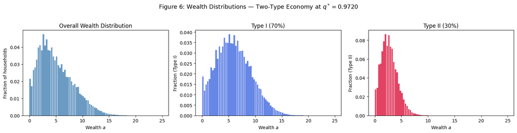

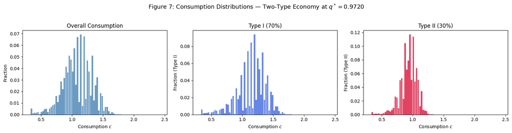

```python
# Part 2: Graphs — wealth and consumption distributions by type

# Re-solve at equilibrium with finer grid for plotting
N_a_2f = 1000
a_max_2f = 30.0
a_grid_2f = np.linspace(0, a_max_2f, N_a_2f)

V_I_fine, g_I_fine, gidx_I_fine = solve_vfi_2(q_star_2, Pi, N_a_2f, a_grid_2f)
dist_I_fine = compute_stationary_dist_2(gidx_I_fine, Pi, N_a_2f)

V_II_fine, g_II_fine, gidx_II_fine = solve_vfi_2(q_star_2, Pi_II, N_a_2f, a_grid_2f)
dist_II_fine = compute_stationary_dist_2(gidx_II_fine, Pi_II, N_a_2f)

# Overall distribution (population-weighted)
dist_overall_2 = omega_I * dist_I_fine + omega_II * dist_II_fine
dist_total_I = dist_I_fine[:, 0] + dist_I_fine[:, 1]
dist_total_II = dist_II_fine[:, 0] + dist_II_fine[:, 1]
dist_total_2 = dist_overall_2[:, 0] + dist_overall_2[:, 1]

# --- Bin for smooth display ---
N_wb = 80
a_up = a_grid_2f[np.max(np.where(dist_total_2 > 1e-8))] * 1.1
wb = np.linspace(0, a_up, N_wb + 1)
wc = 0.5 * (wb[:-1] + wb[1:])
bw = wb[1] - wb[0]

def bin_dist(d, grid, bins):
    out = np.zeros(len(bins)-1)
    idx = np.clip(np.digitize(grid, bins) - 1, 0, len(bins)-2)
    for i in range(len(grid)):
        out[idx[i]] += d[i]
    return out

# Figure 6: Wealth distributions by type
fig, axes = plt.subplots(1, 3, figsize=(16, 4))

axes[0].bar(wc, bin_dist(dist_total_2, a_grid_2f, wb), width=bw*0.9, color='steelblue', alpha=0.8)
axes[0].set_xlabel('Wealth $a$'); axes[0].set_ylabel('Fraction of households')
axes[0].set_title('Overall Wealth Distribution')

axes[1].bar(wc, bin_dist(dist_total_I, a_grid_2f, wb), width=bw*0.9, color='royalblue', alpha=0.8)
axes[1].set_xlabel('Wealth $a$'); axes[1].set_ylabel('Fraction (Type I)')
axes[1].set_title('Type I (70%)')

axes[2].bar(wc, bin_dist(dist_total_II, a_grid_2f, wb), width=bw*0.9, color='crimson', alpha=0.8)
axes[2].set_xlabel('Wealth $a$'); axes[2].set_ylabel('Fraction (Type II)')
axes[2].set_title('Type II (30%)')

plt.suptitle(f'Figure 6: Wealth Distributions — Two-Type Economy at $q^* = {q_star_2:.4f}$', y=1.02, fontsize=13)
plt.tight_layout()
plt.savefig('fig6_wealth_two_type.png', dpi=150, bbox_inches='tight')
plt.show()

# --- Consumption distributions ---
w_star_2 = w_from_q_2(q_star_2)
c_I = np.zeros((N_a_2f, 2))
c_II = np.zeros((N_a_2f, 2))
for j in range(2):
    c_I[:, j] = w_star_2 * s_vals[j] + a_grid_2f - q_star_2 * g_I_fine[:, j]
    c_II[:, j] = w_star_2 * s_vals[j] + a_grid_2f - q_star_2 * g_II_fine[:, j]

# Bin consumption
all_c = np.concatenate([c_I.ravel(), c_II.ravel()])
cb = np.linspace(all_c[all_c > 0].min() * 0.9, all_c.max() * 1.1, 81)
cc = 0.5 * (cb[:-1] + cb[1:])
cbw = cb[1] - cb[0]

def bin_c_dist(c_arr, dist_arr, bins):
    out = np.zeros(len(bins)-1)
    for j in range(2):
        idx = np.clip(np.digitize(c_arr[:, j], bins) - 1, 0, len(bins)-2)
        for i in range(len(c_arr)):
            out[idx[i]] += dist_arr[i, j]
    return out

dc_I = bin_c_dist(c_I, dist_I_fine, cb)
dc_II = bin_c_dist(c_II, dist_II_fine, cb)
dc_all = omega_I * dc_I + omega_II * dc_II

fig, axes = plt.subplots(1, 3, figsize=(16, 4))

axes[0].bar(cc, dc_all, width=cbw*0.9, color='steelblue', alpha=0.8)
axes[0].set_xlabel('Consumption $c$'); axes[0].set_ylabel('Fraction')
axes[0].set_title('Overall Consumption')

axes[1].bar(cc, dc_I, width=cbw*0.9, color='royalblue', alpha=0.8)
axes[1].set_xlabel('Consumption $c$'); axes[1].set_ylabel('Fraction (Type I)')
axes[1].set_title('Type I (70%)')

axes[2].bar(cc, dc_II, width=cbw*0.9, color='crimson', alpha=0.8)
axes[2].set_xlabel('Consumption $c$'); axes[2].set_ylabel('Fraction (Type II)')
axes[2].set_title('Type II (30%)')

plt.suptitle(f'Figure 7: Consumption Distributions — Two-Type Economy at $q^* = {q_star_2:.4f}$', y=1.02, fontsize=13)
plt.tight_layout()
plt.savefig('fig7_consumption_two_type.png', dpi=150, bbox_inches='tight')
plt.show()
```

```python
# Part 2: Statistics — within-type and between-type inequality

def compute_stats(grid, dist_2d):
    """Compute mean, std, skewness from a 2D distribution over (a, s)."""
    E1 = np.sum(grid[:, None] * dist_2d)
    E2 = np.sum(grid[:, None]**2 * dist_2d)
    E3 = np.sum(grid[:, None]**3 * dist_2d)
    var = E2 - E1**2
    std = np.sqrt(max(var, 0))
    skew = (E3 - 3*E1*var - E1**3) / (std**3) if std > 0 else 0.0
    return E1, std, skew

def compute_c_stats(c_arr, dist_2d):
    """Compute mean, std, skewness of consumption."""
    E1 = np.sum(c_arr * dist_2d)
    E2 = np.sum(c_arr**2 * dist_2d)
    E3 = np.sum(c_arr**3 * dist_2d)
    var = E2 - E1**2
    std = np.sqrt(max(var, 0))
    skew = (E3 - 3*E1*var - E1**3) / (std**3) if std > 0 else 0.0
    return E1, std, skew

# --- Within-type wealth stats ---
mean_w_I, std_w_I, skew_w_I = compute_stats(a_grid_2f, dist_I_fine)
mean_w_II, std_w_II, skew_w_II = compute_stats(a_grid_2f, dist_II_fine)
mean_w_all, std_w_all, skew_w_all = compute_stats(a_grid_2f, dist_overall_2)

print("=== Wealth Statistics ===")
print(f"{'':12s} {'Mean':>10s} {'Std':>10s} {'Skewness':>10s}")
print("-" * 44)
print(f"{'Type I':12s} {mean_w_I:10.4f} {std_w_I:10.4f} {skew_w_I:10.4f}")
print(f"{'Type II':12s} {mean_w_II:10.4f} {std_w_II:10.4f} {skew_w_II:10.4f}")
print(f"{'Overall':12s} {mean_w_all:10.4f} {std_w_all:10.4f} {skew_w_all:10.4f}")

# --- Within-type consumption stats ---
mean_c_I, std_c_I, skew_c_I = compute_c_stats(c_I, dist_I_fine)
mean_c_II, std_c_II, skew_c_II = compute_c_stats(c_II, dist_II_fine)
c_overall = omega_I * c_I  # not meaningful to add, use binned approach
# For overall consumption stats, weight the type-specific distributions
dist_c_overall = omega_I * dist_I_fine  # placeholder
c_all_combined = np.concatenate([c_I.ravel(), c_II.ravel()])
d_all_combined = np.concatenate([omega_I * dist_I_fine.ravel(), omega_II * dist_II_fine.ravel()])
mean_c_all = np.sum(c_all_combined * d_all_combined)
var_c_all = np.sum(c_all_combined**2 * d_all_combined) - mean_c_all**2
std_c_all = np.sqrt(max(var_c_all, 0))
skew_c_all = (np.sum(c_all_combined**3 * d_all_combined) - 3*mean_c_all*var_c_all - mean_c_all**3) / (std_c_all**3) if std_c_all > 0 else 0.0

print("\n=== Consumption Statistics ===")
print(f"{'':12s} {'Mean':>10s} {'Std':>10s} {'Skewness':>10s}")
print("-" * 44)
print(f"{'Type I':12s} {mean_c_I:10.4f} {std_c_I:10.4f} {skew_c_I:10.4f}")
print(f"{'Type II':12s} {mean_c_II:10.4f} {std_c_II:10.4f} {skew_c_II:10.4f}")
print(f"{'Overall':12s} {mean_c_all:10.4f} {std_c_all:10.4f} {skew_c_all:10.4f}")

# --- Income stats ---
r_star_2 = r_from_q_2(q_star_2)
inc_I = np.zeros((N_a_2f, 2))
inc_II = np.zeros((N_a_2f, 2))
for j in range(2):
    inc_I[:, j] = w_star_2 * s_vals[j] + (r_star_2 - delta) * a_grid_2f
    inc_II[:, j] = w_star_2 * s_vals[j] + (r_star_2 - delta) * a_grid_2f

mean_y_I, std_y_I, skew_y_I = compute_c_stats(inc_I, dist_I_fine)
mean_y_II, std_y_II, skew_y_II = compute_c_stats(inc_II, dist_II_fine)

inc_combined = np.concatenate([inc_I.ravel(), inc_II.ravel()])
d_combined = np.concatenate([omega_I * dist_I_fine.ravel(), omega_II * dist_II_fine.ravel()])
mean_y_all = np.sum(inc_combined * d_combined)
var_y_all = np.sum(inc_combined**2 * d_combined) - mean_y_all**2
std_y_all = np.sqrt(max(var_y_all, 0))
skew_y_all = (np.sum(inc_combined**3 * d_combined) - 3*mean_y_all*var_y_all - mean_y_all**3) / (std_y_all**3) if std_y_all > 0 else 0.0

print("\n=== Income Statistics ===")
print(f"{'':12s} {'Mean':>10s} {'Std':>10s} {'Skewness':>10s}")
print("-" * 44)
print(f"{'Type I':12s} {mean_y_I:10.4f} {std_y_I:10.4f} {skew_y_I:10.4f}")
print(f"{'Type II':12s} {mean_y_II:10.4f} {std_y_II:10.4f} {skew_y_II:10.4f}")
print(f"{'Overall':12s} {mean_y_all:10.4f} {std_y_all:10.4f} {skew_y_all:10.4f}")

# --- Between-type differences ---
print("\n=== Between-Type Differences ===")
print(f"Mean wealth gap (I - II):      {mean_w_I - mean_w_II:+.4f}")
print(f"Mean consumption gap (I - II): {mean_c_I - mean_c_II:+.4f}")
print(f"Mean income gap (I - II):      {mean_y_I - mean_y_II:+.4f}")
print(f"Std wealth — Type I: {std_w_I:.4f}, Type II: {std_w_II:.4f}")
print(f"Std consumption — Type I: {std_c_I:.4f}, Type II: {std_c_II:.4f}")
```

```
=== Wealth Statistics ===
                   Mean        Std   Skewness
--------------------------------------------
Type I           5.9927     3.2409     0.3960
Type II          2.7441     1.5310     0.6385
Overall          5.0181     3.2050     0.7273

=== Consumption Statistics ===
                   Mean        Std   Skewness
--------------------------------------------
Type I           1.1533     0.2330    -0.7268
Type II          0.9339     0.1348    -0.8869
Overall          1.0875     0.2314    -0.2406

=== Income Statistics ===
                   Mean        Std   Skewness
--------------------------------------------
Type I           1.1581     0.5236    -0.4908
Type II          0.9361     0.5162     0.0004
Overall          1.0915     0.5312    -0.3278

=== Between-Type Differences ===
Mean wealth gap (I - II):      +3.2486
Mean consumption gap (I - II): +0.2194
Mean income gap (I - II):      +0.2220
Std wealth — Type I: 3.2409, Type II: 1.5310
Std consumption — Type I: 0.2330, Type II: 0.1348
```

**Discussion: Impact of ex-ante heterogeneity on equilibrium and inequality**

**Aggregates $\{L, K, Y\}$:** Type II workers have invariant distribution $\lambda_{II} = (0.5, 0.5)$ versus Type I's $(0.375, 0.625)$. Since Type II spends more time in the low-skill state, $\bar{L}_{II} = 0.625 < \bar{L}_I = 0.71875$. The population-weighted $\bar{L}$ therefore falls. With lower effective labor supply, both $K$ and $Y$ decrease in equilibrium (since $K = (\alpha A / r)^{1/(1-\alpha)} \bar{L}$ scales linearly in $\bar{L}$, and $Y = AK^\alpha \bar{L}^{1-\alpha}$).